# 金融时间序列数据获取

## finance-quant

```r
library(tidyverse)
library(tidyquant)
```

```r
prices <- tq_get("AAPL",
  get = "stock.prices",
  from = "2000-01-01",
  to = "2021-12-31"
)
prices
```

```
## # A tibble: 5,535 × 8
##    symbol date        open  high   low close     volume adjusted
##    <chr>  <date>     <dbl> <dbl> <dbl> <dbl>      <dbl>    <dbl>
##  1 AAPL   2000-01-03 0.936 1.00  0.908 0.999  535796800    0.851
##  2 AAPL   2000-01-04 0.967 0.988 0.903 0.915  512377600    0.779
##  3 AAPL   2000-01-05 0.926 0.987 0.920 0.929  778321600    0.790
##  4 AAPL   2000-01-06 0.948 0.955 0.848 0.848  767972800    0.722
##  5 AAPL   2000-01-07 0.862 0.902 0.853 0.888  460734400    0.756
##  6 AAPL   2000-01-10 0.911 0.913 0.846 0.873  505064000    0.743
##  7 AAPL   2000-01-11 0.857 0.887 0.808 0.828  441548800    0.705
##  8 AAPL   2000-01-12 0.848 0.853 0.772 0.778  976068800    0.663
##  9 AAPL   2000-01-13 0.844 0.882 0.826 0.864 1032684800    0.735
## 10 AAPL   2000-01-14 0.893 0.913 0.887 0.897  390376000    0.763
## # ℹ 5,525 more rows
```

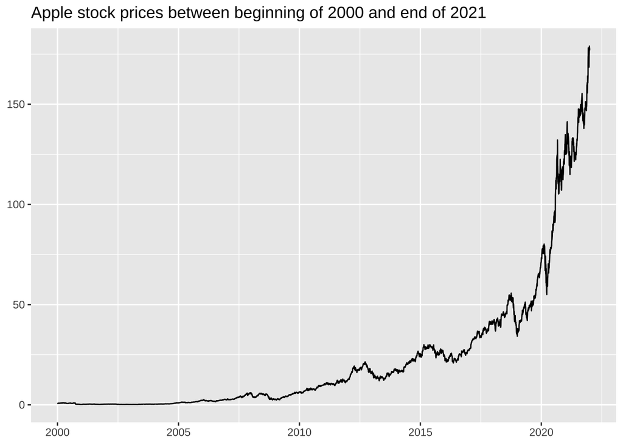

```r
prices %>%
  ggplot(aes(x = date, y = adjusted)) +
  geom_line() +
  labs(
    x = NULL,
    y = NULL,
    title = "Apple stock prices between beginning of 2000 and end of 2021"
  )
```

```r
prices
```

```
## # A tibble: 5,535 × 8
##    symbol date        open  high   low close     volume adjusted
##    <chr>  <date>     <dbl> <dbl> <dbl> <dbl>      <dbl>    <dbl>
##  1 AAPL   2000-01-03 0.936 1.00  0.908 0.999  535796800    0.851
##  2 AAPL   2000-01-04 0.967 0.988 0.903 0.915  512377600    0.779
##  3 AAPL   2000-01-05 0.926 0.987 0.920 0.929  778321600    0.790
##  4 AAPL   2000-01-06 0.948 0.955 0.848 0.848  767972800    0.722
##  5 AAPL   2000-01-07 0.862 0.902 0.853 0.888  460734400    0.756
##  6 AAPL   2000-01-10 0.911 0.913 0.846 0.873  505064000    0.743
##  7 AAPL   2000-01-11 0.857 0.887 0.808 0.828  441548800    0.705
##  8 AAPL   2000-01-12 0.848 0.853 0.772 0.778  976068800    0.663
##  9 AAPL   2000-01-13 0.844 0.882 0.826 0.864 1032684800    0.735
## 10 AAPL   2000-01-14 0.893 0.913 0.887 0.897  390376000    0.763
## # ℹ 5,525 more rows
```

```r
returns <- prices %>%
  arrange(date) %>%
  mutate(ret = lead(adjusted) / adjusted - 1) %>%
  select(symbol, date, ret)
returns <- returns %>%
  drop_na(ret)
returns
```

```
## # A tibble: 5,534 × 3
##    symbol date           ret
##    <chr>  <date>       <dbl>
##  1 AAPL   2000-01-03 -0.0843
##  2 AAPL   2000-01-04  0.0146
##  3 AAPL   2000-01-05 -0.0865
##  4 AAPL   2000-01-06  0.0474
##  5 AAPL   2000-01-07 -0.0176
##  6 AAPL   2000-01-10 -0.0512
##  7 AAPL   2000-01-11 -0.0600
##  8 AAPL   2000-01-12  0.110
##  9 AAPL   2000-01-13  0.0381
## 10 AAPL   2000-01-14  0.0348
## # ℹ 5,524 more rows
```

计算分位数：

```r
quantile_05 <- quantile(returns %>% pull(ret) * 100, probs = 0.05)
```

这里的`pull`类似于`$`操作运算，拿出需要的变量，但可以拿出多个变量，也类似于`select`运算。

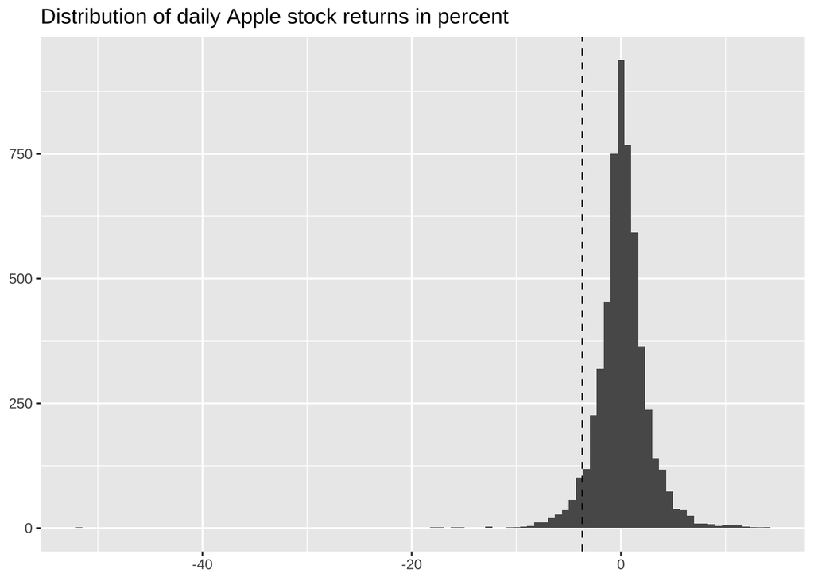

```r
returns%>%
  ggplot(aes(x = ret * 100)) +
  geom_histogram(bins = 100) +
  geom_vline(aes(xintercept = quantile_05),
    linetype = "dashed"
  ) +
  labs(
    x = NULL,
    y = NULL,
    title = "Distribution of daily Apple stock returns in percent"
  )
```

获得指数的`tq_index`

```r
ticker <- tq_index("DOW")
ticker
```

```
## # A tibble: 30 × 8
##    symbol company      identifier sedol weight sector shares_held local_currency
##    <chr>  <chr>        <chr>      <chr>  <dbl> <chr>        <dbl> <chr>
##  1 UNH    UnitedHealt… 91324P10   2917… 0.0965 Healt…     5635932 USD
##  2 GS     Goldman Sac… 38141G10   2407… 0.0646 Finan…     5635932 USD
##  3 HD     Home Depot … 43707610   2434… 0.0583 Consu…     5635932 USD
##  4 MSFT   Microsoft C… 59491810   2588… 0.0570 Infor…     5635932 USD
##  5 MCD    McDonald's … 58013510   2550… 0.0553 Consu…     5635932 USD
##  6 AMGN   Amgen Inc.   03116210   2023… 0.0479 Healt…     5635932 USD
##  7 V      Visa Inc. C… 92826C83   B2PZ… 0.0457 Finan…     5635932 USD
##  8 CAT    Caterpillar… 14912310   2180… 0.0450 Indus…     5635932 USD
##  9 BA     Boeing Comp… 09702310   2108… 0.0406 Indus…     5635932 USD
## 10 CRM    Salesforce … 79466L30   2310… 0.0385 Infor…     5635932 USD
## # ℹ 20 more rows
```

### Famafrench 数据

Fama-French的三因子模型/五因子的数据可直接通过`frenchdata`包来下载，不再需要上french数据官网下载。

```r
start_date <- ymd("1960-01-01")
end_date <- ymd("2021-12-31")
```

```r
library(frenchdata)
start_date =
factors_ff_monthly_raw <- download_french_data("Fama/French 3 Factors")
factors_ff_monthly <- factors_ff_monthly_raw$subsets$data[[1]] %>%
  transmute(
    month = floor_date(ymd(str_c(date, "01")), "month"),
    rf = as.numeric(RF) / 100,
    mkt_excess = as.numeric(`Mkt-RF`) / 100,
    smb = as.numeric(SMB) / 100,
    hml = as.numeric(HML) / 100
  )
head(factors_ff_monthly)
```

```
## # A tibble: 6 × 5
##   month          rf mkt_excess     smb     hml
##   <date>      <dbl>      <dbl>   <dbl>   <dbl>
## 1 1926-07-01 0.0022     0.0296 -0.0256 -0.0243
## 2 1926-08-01 0.0025     0.0264 -0.0117  0.0382
## 3 1926-09-01 0.0023     0.0036 -0.014   0.0013
## 4 1926-10-01 0.0032    -0.0324 -0.0009  0.007
## 5 1926-11-01 0.0031     0.0253 -0.001  -0.0051
## 6 1926-12-01 0.0028     0.0262 -0.0003 -0.0005
```

```r
industries_ff_monthly_raw <- download_french_data("10 Industry Portfolios")
industries_ff_monthly <- industries_ff_monthly_raw$subsets$data[[1]] |>
  mutate(month = floor_date(ymd(str_c(date, "01")), "month")) |>
  mutate(across(where(is.numeric), ~ . / 100)) |>
  select(month, everything(), -date)
head(industries_ff_monthly)
```

```
## # A tibble: 6 × 11
##   month        NoDur   Durbl   Manuf   Enrgy   HiTec   Telcm   Shops    Hlth
##   <date>       <dbl>   <dbl>   <dbl>   <dbl>   <dbl>   <dbl>   <dbl>   <dbl>
## 1 1926-07-01  0.0145  0.156   0.0469 -0.0118  0.029   0.0083  0.0011  0.0177
## 2 1926-08-01  0.0397  0.0368  0.0281  0.0347  0.0266  0.0217 -0.0071  0.0425
## 3 1926-09-01  0.0114  0.048   0.0115 -0.0339 -0.0038  0.0241  0.0021  0.0069
## 4 1926-10-01 -0.0124 -0.0823 -0.0363 -0.0078 -0.0458 -0.0011 -0.0229 -0.0057
## 5 1926-11-01  0.052  -0.0019  0.041   0.0001  0.0471  0.0163  0.0643  0.0542
## 6 1926-12-01  0.0082  0.0989  0.0374  0.0282 -0.0002  0.0199  0.0062  0.0011
## # ℹ 2 more variables: Utils <dbl>, Other <dbl>
```

### 宏观数据

```r
library(readxl)
library(googledrive)
library(tidyquant)
drive_deauth()
```

```r
cpi_monthly <- tq_get("CPIAUCNS",
  get = "economic.data"
) |>
  transmute(
    month = floor_date(date, "month"),
    cpi = price / price[month == max(month)]
  )
tail(cpi_monthly)
```

```
## # A tibble: 6 × 2
##   month        cpi
##   <date>     <dbl>
## 1 2022-09-01 0.987
## 2 2022-10-01 0.991
## 3 2022-11-01 0.990
## 4 2022-12-01 0.987
## 5 2023-01-01 0.994
## 6 2023-02-01 1
```

最新的数据在2023年2月。

还有一些其他的数据来源，tidyfinance这本书中有一些总结https://www.tidy-finance.org/other-data-providers.html

## Resource

- [tidyfinance](https://www.tidy-finance.org/index.html)
- [金融时间序列分析](https://www.math.pku.edu.cn/teachers/lidf/course/fts/ftsnotes/html/_ftsnotes/rsoft.html#rsoft-ts-bgets)